# [Bet, Sweat, and Forget.](https://open.spotify.com/show/1bABVhkwnd3sDaBSZLC0oY)

#### Each week during the NFL season, Ryan Brill and Nick Miller make $50 worth of NFL bets on the [Bet, Sweat, and Forget](https://open.spotify.com/show/1bABVhkwnd3sDaBSZLC0oY) podcast, competing for glory and the title of “best bettor”. Check out the podcast on Apple Podcasts and [Spotify](https://open.spotify.com/show/1bABVhkwnd3sDaBSZLC0oY).

## 2020 NFL Season.

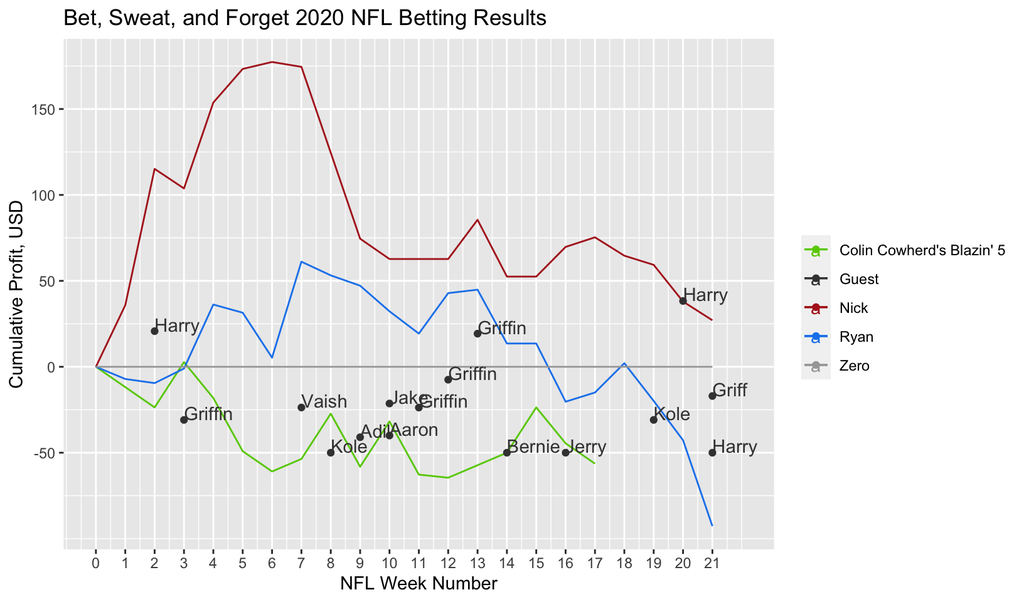

#### 2020 Bet, Sweat, and Forget Awards

- **Champion:** Nick
- **Most Profitable Guest of the Year:** Harry
- **Most Entertaining Guest of the Year:** Jerry
- **Most Improved Bettor:** Griffin
- **-$50 Club:** Nick (2x), Kole, Bernie, Jerry, Harry, Ryan
- **Official NFL G.O.A.T.:** Tom Brady
- **Loser’s Punishment:** Ryan shall purchase and proudly wear Tom Brady gear

#### 2020 Miscellaneous

- You might be wondering: Why did Ryan tank in the playoffs? Well, he bet against the Bucs for 3 straight rounds in the playoffs.
- Note that Colin Cowherd’s 2020 Blazin’ 5 cumulative profit is calculated by placing $10 on each of his 5 weekly NFL pointspread bets, using a -110 moneyline for each bet.
- [2020 NFL Betting Details.](https://docs.google.com/spreadsheets/d/13TNrDf-RFrJfA36LXjcGHZ5fr_W4pD1yO2_RyniTxww/edit?usp=sharing)
- [Are Ryan Brill and Nick Miller better at sports betting than a monkey?](https://ryansbrill.com/ryan_vs_monkey/)

## 2019 NFL Season.

#### 2019 Bet, Sweat, and Forget Awards

- **Champion:** Ryan
- **Guest of the Year:** Harry, for picking the Chiefs before the playoffs began
- **Loser’s Punishment:** [[Nick became the CEO of Ryan’s dream company, Shoober]](https://www.youtube.com/watch?v=LjBJNchf-BQ)